# (How COVID19 Affected the flight of the USA

## by Abdulmalik Alaql

## Investigation Overview

We will see how COVID-19 affected the flight of the USA.

How the number of flights changed before and after COVID-19 ?

How the flights delay changed before and after COVID-19 ?

Cancelled Flight

Reason for Cancellation

## Dataset Overview

The dataset is about daily flights on USA on April-2019 and April-2020 months only. The dataset comes from https://www.transtats.bts.gov

## How the number of flights changed before and after COVID-19 ?

We can see that 2019 has more fligh than 2020, Number of flights on 2019 is '606507' and number of flights on 2020 is '254516.

In 2019 Monday and Tuesday was has the highest number of flights. In 2020 Wednesday and Thursday are the days with highest number of flights. maybe everyone wants to avoid crowding :)

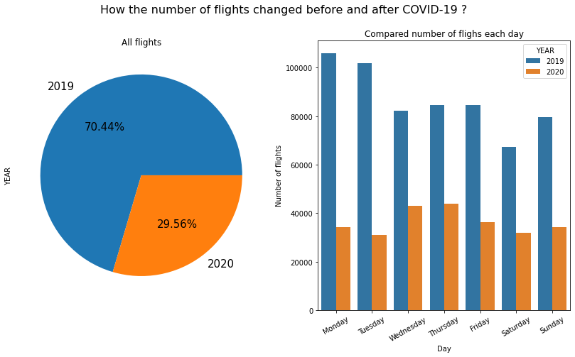

```python
plt.figure(figsize = [14, 7])
plt.subplot(1, 2, 1)
data_df.YEAR.value_counts().plot(kind='pie',fontsize =15, autopct='%1.2f%%');
plt.title('All flights');
plt.subplot(1, 2, 2)


sb.countplot(data=data_df , x='day' ,hue='YEAR', order = ['Monday','Tuesday','Wednesday','Thursday','Friday','Saturday','Sunday']);
plt.xlabel('Day');
plt.ylabel('Number of flights');
plt.xticks(rotation = 30);
plt.title('Compared number of flighs each day');
plt.suptitle('How the number of flights changed before and after COVID-19 ?',fontsize=16);
```

## How the flights delay changed before and after COVID-19 ?

We can see the performance in 2020 much better than 2019. in 2020 most of the flights has negative values for departure delay and arrival delay (negative numbers mean early departures and early arrivals

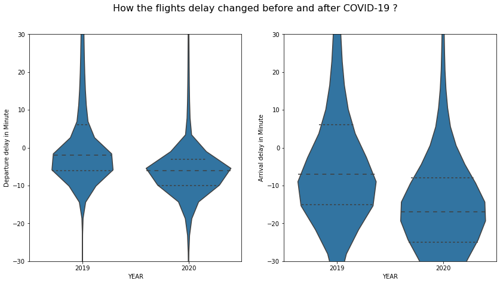

```python
base_color = sb.color_palette()[0]
plt.figure(figsize = [14, 7])
plt.subplot(1, 2, 1)
sb.violinplot(data=data_df, x='YEAR', y='DEP_DELAY',  color=base_color, inner='quartile');
plt.ylim((-30,30));
plt.xlabel('YEAR');
plt.ylabel('Departure delay in Minute');
plt.subplot(1, 2, 2)
sb.violinplot(data=data_df, x='YEAR', y='ARR_DELAY',  color=base_color, inner='quartile');
plt.ylim((-30,30));
plt.xlabel('YEAR');
plt.ylabel('Arrival delay in Minute');
plt.suptitle('How the flights delay changed before and after COVID-19 ?',fontsize=16);
```

## Cancelled Flight

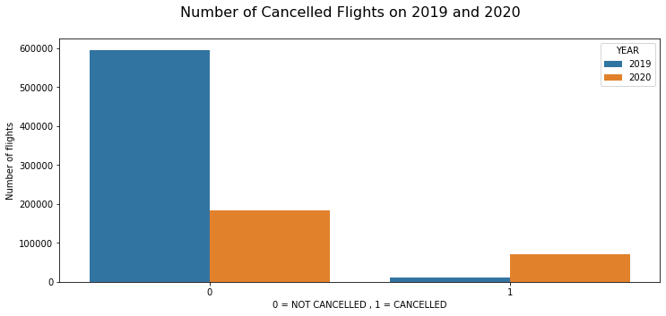

```python
plt.figure(figsize = [12, 5])
sb.countplot(data=data_df , x='CANCELLED' ,hue='YEAR' );
plt.xlabel('0 = NOT CANCELLED , 1 = CANCELLED');
plt.ylabel('Number of flights');
plt.suptitle('Number of Cancelled Flights on 2019 and 2020',fontsize=16);
```

## Reason for Cancellation

We can see the reason for cancellation of the flights is very diffrent. non of 2019 flights was cancelled for security reason while in 2020 almost every flights was cancelled for security reason.

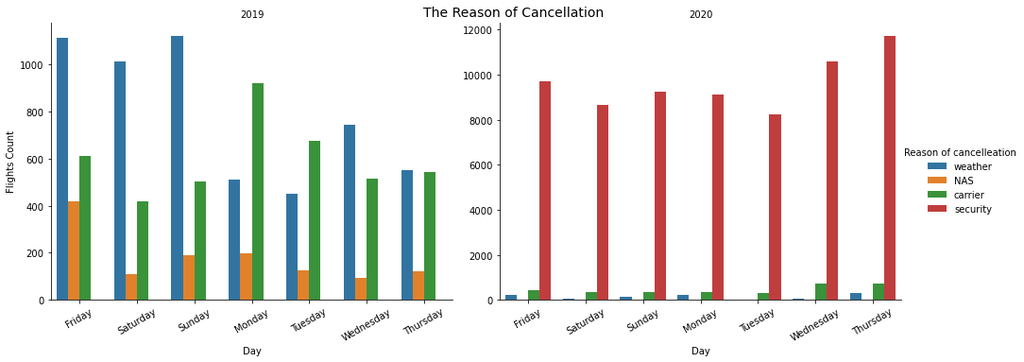

```python
My_figure=sb.catplot(data=data_df, x='day', col="YEAR", hue='CANCELLATION_CODE', kind='count', aspect=20/15,
                 sharey=False);
My_figure.set_xticklabels(rotation=30);
My_figure.set_axis_labels('Day', 'Flights Count');
My_figure._legend.set_title('Reason of cancelleation');
My_figure.set_titles('{col_name}');
plt.suptitle('The Reason of Cancellation',fontsize=14);
```